# Covid19_analysis_DE

Eszter Diamant

2020 11 29

## R Markdown

The aim of this analysis to identify linear regression between number of confirmed COVID-19 cases and death due to COVID-19. The main research question whether the correlation is high or low and by this it can be determine which countries managed to save their people efficiently or not. The dataset contain data on countries, their population, the number of confirmed COVID-19 cases in the country, the number of death resulted from the infection, the number of recovered cases, and the number of currently active COVID-19 cases. Considering the high differences among the popuation, scaling was implemented during the analysis. Also, some extreme values were found such as Qatar and Singapore where high number of confirmed infection resulted in significantly lower number of death due to the quality of the healthcare system. However, because of the aim of the research question, these extreme values were kept. On the other hand, ue to errors in the regression analysis, those countries were droped where there were not deaths which might influence potential results.

## Summary statistics

The mean of the distribution is 25,6647 while the median is 21,523. It is already indicates a high skeweness that is more than 7 for confirmed covid cases and more than 6 for deaths, meaning a long right tail in both distribution.

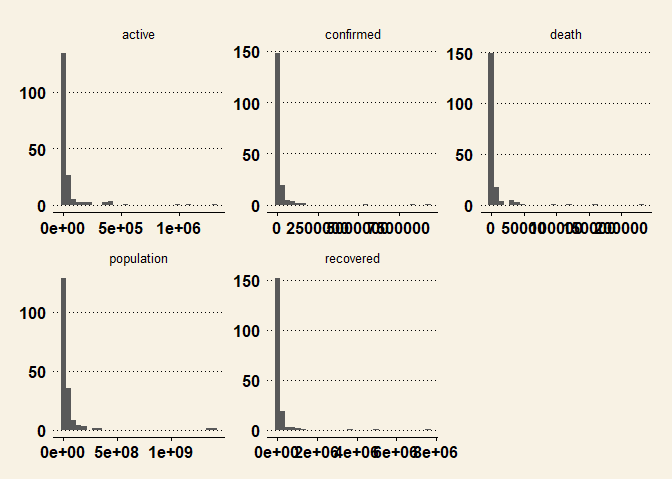

## Investigate the transfomration of variables:

Considering the fact that the analysis used number of confirmed cases and number of deaths, significant transformation among he values did not occur.

## Investigate different models:

Make the three models:

1. level-level:

   ```
      (chart 1): reg1: death = alpha + beta * confirmed
      (chart 5): reg2: death = alpha + beta_1 * confirmed + beta_2 * confirmed^2
      (chart 6): reg3: death = alpha + beta_1 * confirmed + beta_2 * confirmed^2 + beta_3 * confirmed^3
   ```

2. log -log:

   ```
     (chart 4): reg4: log_death = alpha + beta * log_conf
     (chart 7): reg5: log_death = alpha + beta_1 * log_conf + beta_2 * log_conf^2
     (chart 8): reg6: log_death = alpha + beta_1 * log_conf + beta_2 * log_conf^2 + beta_3 * log_conf^3
     (chart 9): reg7: log_death = alpha + beta_1 * log_conf * 1(log_conf < 7) + beta_2 * log_conf * 1(log_conf >= 7)
   ```

3. extra: weighted-ols:

   ```
     chart 10): reg8: log_death = alpha + beta* log_conf, weights: population
   ```

## Model choice

Based on model comparison our chosen model is reg4 - log_death ~ log_conf

Substantive: - the log-log transformation gives the most fitting linear model - the coefficients are meaningful

## Hypothesis testing:

The hypothesis test whether the ß of chosen model can equal to zero:

H0: ß = 0 HA: ß != 0

Because the p-value is lower than 0.05 the null hypothesis, that ß=0, can be rejected.

```
##
## Call:
## lm_robust(formula = log_death ~ log_conf, data = df, se_type = "HC2")
##
## Standard error type:  HC2
##
## Coefficients:
##             Estimate Std. Error t value  Pr(>|t|) CI Lower CI Upper  DF
## (Intercept)   -4.241    0.30343  -13.98 6.074e-30  -4.8396   -3.642 168
## log_conf       1.018    0.02786   36.53 7.869e-82   0.9626    1.073 168
##
## Multiple R-squared:  0.8901 ,    Adjusted R-squared:  0.8895
## F-statistic:  1334 on 1 and 168 DF,  p-value: < 2.2e-16
```

## Analysis of residuals:

Countries that relatively saved the most people due to COVID-19:

| country | log_death | reg4_y_pred | reg4_res |
| --- | --- | --- | --- |
| Burundi | 0.000000 | 2.249810 | -2.249810 |
| Iceland | 2.484907 | 4.411990 | -1.927083 |
| Qatar | 5.446737 | 7.764013 | -2.317276 |
| Singapore | 3.332205 | 6.920522 | -3.588317 |
| Sri Lanka | 3.044522 | 5.258958 | -2.214436 |

Countries that relatively lost the most people due to COVID-19:

| country | log_death | reg4_y_pred | reg4_res |
| --- | --- | --- | --- |
| Chad | 4.5849675 | 3.200339 | 1.384628 |
| Ecuador | 9.4487272 | 8.011783 | 1.436945 |
| Fiji | 0.6931472 | -0.652333 | 1.345480 |
| Mexico | 11.4306302 | 9.747078 | 1.683552 |
| Yemen | 6.3985949 | 3.525310 | 2.873285 |

## Appendix:

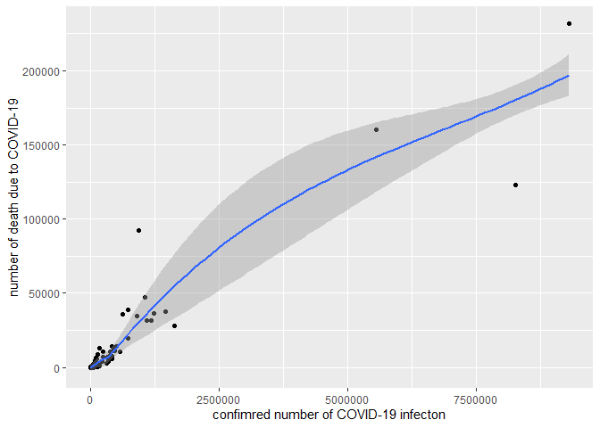

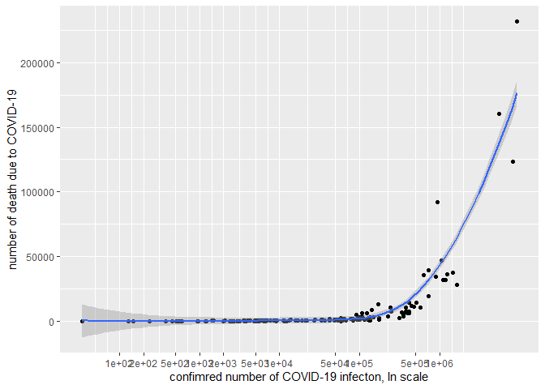

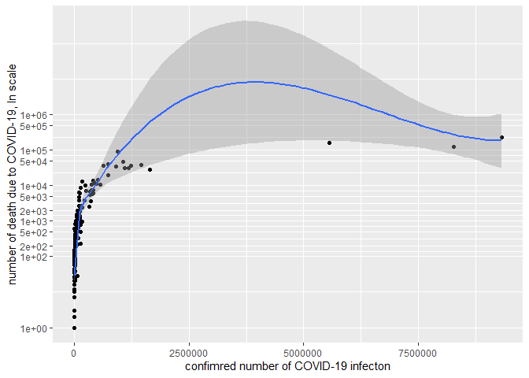

Chart 4: log - log regression linear regression

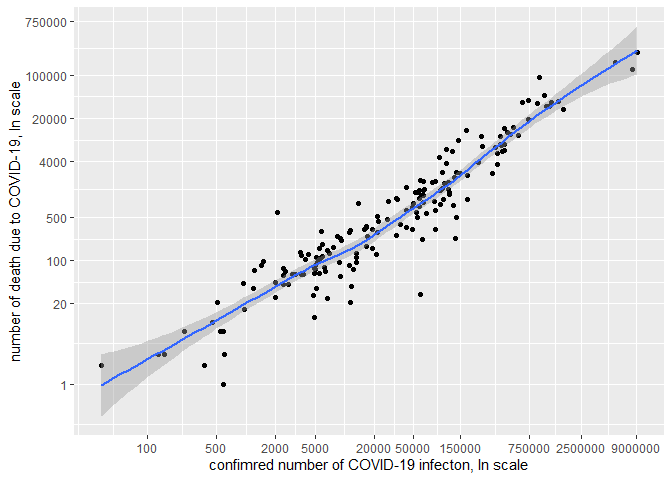

Chart 5: level-level quadratic regression

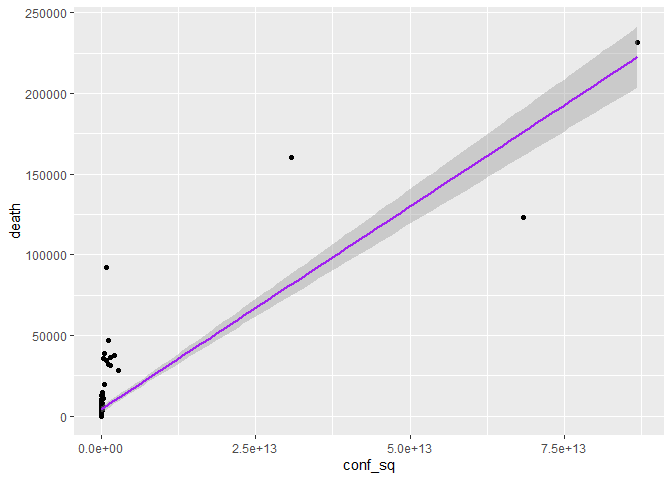

Chart 6: level - level cubic regression

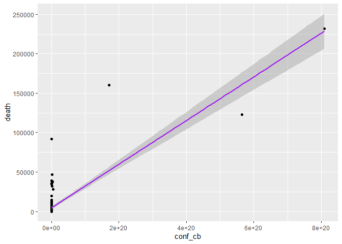

chart 7: log(death) - log(confirmed) quadratic regression

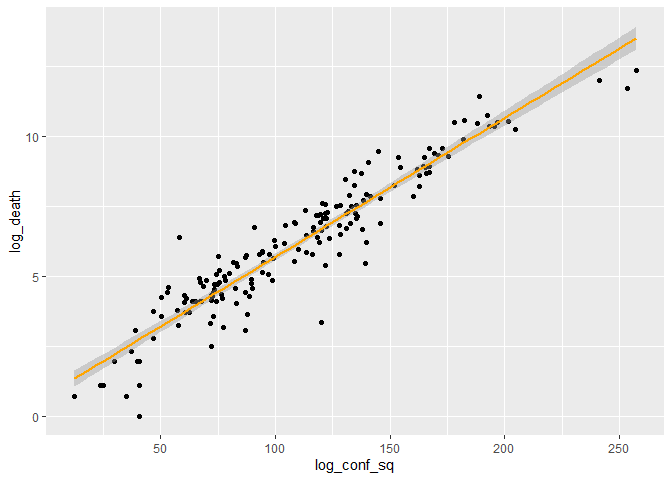

chart 8: log(death) - log(confirmed) cubic regression

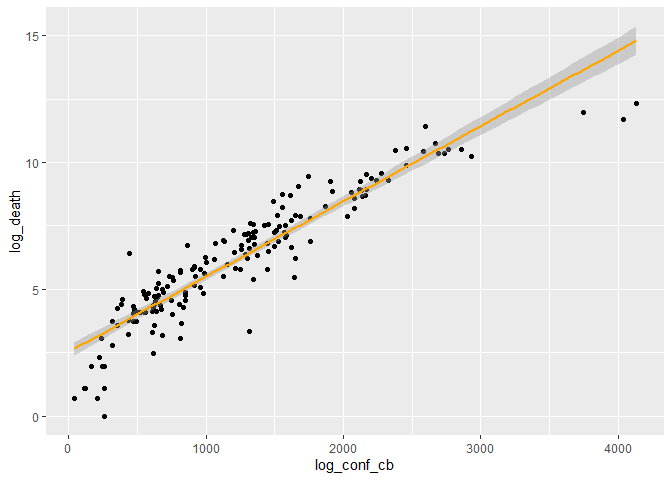

chart 9: Piecewise linear spline regression

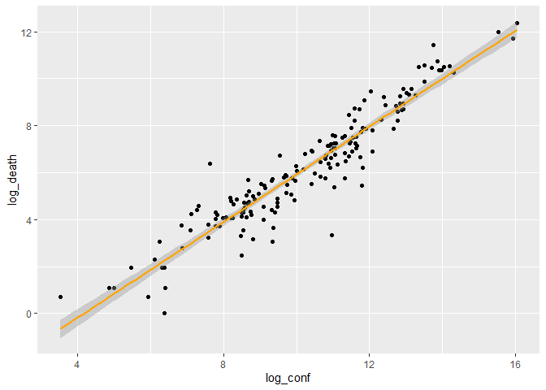

chart 10: Weighted linear regression, using population as weights

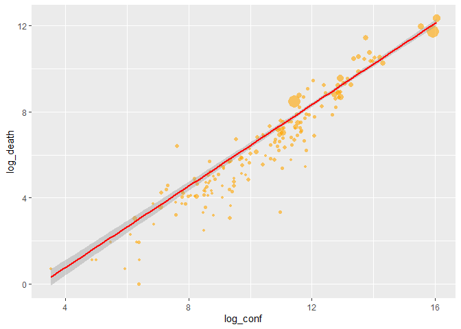

chart 11: Model comparisons

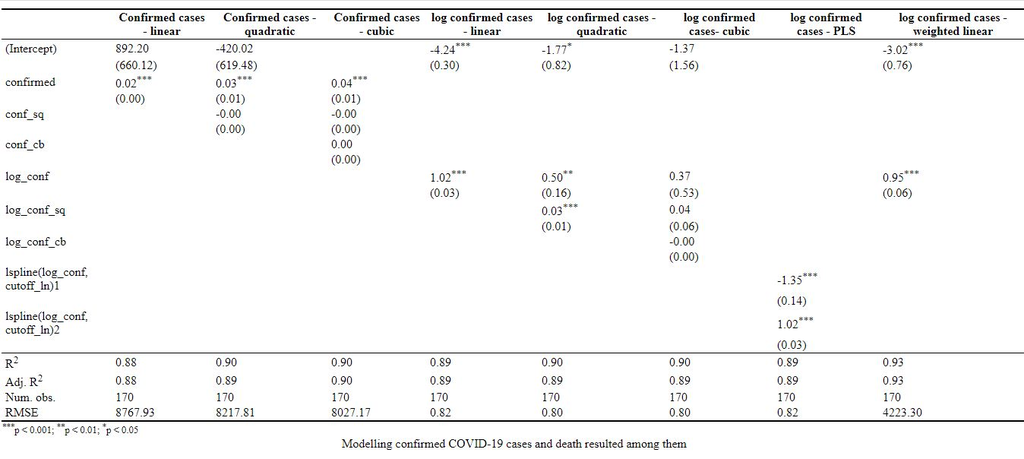

Regression Models

## Github repository:

[Github](https://github.com/DiamantEszter97/Coding1-DA-Assigment1/tree/master/Covid19-Regression)